# Cyclistic Bike Share Analysis

Franco Nicolay

2025-10-25

# **Case Study: Cyclistic Bike Share**

## **Executive Summary**

This report analyzes October 2025 Cyclistic bike-share trip data to understand how casual riders and annual members use the service differently. The goal is to uncover behavioral patterns that can inform targeted marketing strategies aimed at increasing annual memberships, which are substantially more profitable for the company.

The analysis reveals key differences between user groups. Casual riders tend to take significantly longer trips and concentrate their usage on weekends and recreational hours. In contrast, annual members ride more frequently, with consistent patterns during weekdays and commuting hours. These distinct behaviors suggest meaningful opportunities to convert casual riders into annual members through targeted offerings and messaging.

Based on these insights, this report recommends:

1. Launching a **weekend-focused membership tier** to appeal to recreational riders.
2. Implementing **usage-based incentives** for casual riders to encourage frequent riding.
3. Deploying **digital media campaigns** tailored to tourists and occasional users.

These actions aim to increase membership conversion rates and support Cyclistic’s long-term growth strategy.

## **Phase 1: Ask**

### **1.1 Business Problem**

Cyclistic’s future growth depends on increasing the number of annual members, who generate significantly higher long-term revenue compared to casual riders. To design an effective marketing strategy, the company first needs to understand how these two customer groups use the service differently. These insights will guide the development of campaigns that encourage casual riders to convert into annual members.

### **1.2 Key Stakeholders**

- **Lily Moreno** (Director of Marketing)
- **Cyclistic Marketing Analytics Team**
- **Cyclistic Executive Team** (final decision-makers)

### **1.3 Business Task**

Analyze Cyclistic’s historical trip data to identify how annual members and casual riders use the bike-share service differently. The insights from this analysis will be used to develop a targeted marketing strategy aimed at converting casual riders into annual members.

## **Phase 2: Prepare**

### **2.1 Data Sources**

For this analysis, I used publicly available Divvy bike-share data (Cyclistic is the fictional name used for this case study). The dataset originates from Motivate International Inc. and is provided under the Divvy Data License Agreement, which permits public use while protecting rider privacy.

- **Dataset**: Divvy trip data (Cyclistic is fictional name for Divvy)
- **Main file**: `202510-divvy-tripdata.csv`
- **Period**: October 2025
- **License**: Motivate International Inc. under public license

### **2.2 Dataset Characteristics**

**Dataset Structure:**

- **Rows:** 646,039 rides
- **Columns:** 13 variables
- **Time period:** October 1-31, 2025
- **File format:** CSV with 13 columns
- **Primary groups:** member_casual (member: 422,029, casual: 224,010)

**Data Quality Check:**

- Rides with negative duration: 0
- Rides with 0 minute duration: 0

The dataset contains 646,039 individual bike trips with 13 variables, including timestamps, station information, and rider type. The data covers the full month with no timing errors. The rider split is 65% members and 35% casual riders.

### **2.3 Data Quality Assessment (ROCCC)**

- **Reliable**: ✓ First-party data from actual bike-share system
- **Original**: ✓ Raw trip-level data, not aggregated
- **Comprehensive**: ✓ 646,039 rides, good representation
- **Current**: ✓ October 2025
- **Cited**: ✓ Properly licensed from Motivate International Inc.

### **2.4 Licensing, Privacy, and Security**

The dataset complies with Divvy’s public license, which allows academic and analytical use. It contains no personally identifiable information (PII). All user IDs, payment methods, and location histories are removed to protect rider privacy. Only operational trip-level data is provided.

### **2.5 Data Integrity and Issues Identified**

These issues are addressed and documented in detail in **Phase 3: Process**.

### **2.6 Relevance to the Business Task**

This dataset provides all required variables to:

- Compare trip duration between rider types
- Analyze usage patterns by day of week and time of day
- Identify behavioral differences between casual riders and annual members
- Generate insights that support marketing strategies aimed at increasing membership conversions

Thus, the dataset is appropriate for answering the business question:

**“How do annual members and casual riders use Cyclistic bikes differently?”**

### **2.7 Limitations of the Data**

This analysis is based on a single month of data (October 2025). This provides a valuable snapshot but has one key limitation:

Seasonality: The findings are specific to an autumn month. User behavior (especially casual and tourist behavior) is likely very different in summer (July) or winter (January).

The conclusions drawn here are valid for the period analyzed, but they should be validated against a full 12-month dataset to confirm year-round patterns before launching large-scale annual marketing campaigns.

## **Phase 3: Process**

### **3.1 Data Cleaning and Transformation**

The following steps were applied to prepare the data for analysis:

1. Ensure timestamps are POSIXct (important for difftime, wday, hour)
2. Basic integrity checks (count invalid / missing records before modifying)
3. Create derived fields required for analysis

### **3.2 Data Integrity Validation**

4. Remove obvious errors and extreme outliers:
- negative or zero durations
- extremely long rides (> 24 hours)
- missing coordinates if those rows are not useful for spatial analysis
- remove exact duplicates (same ride_id)
5. Verification outputs (kept both numeric and formatted for display)

**Data Cleaning Summary**

| Metric | Value |
| --- | --- |
| Original rides | 646039 |
| Cleaned rides | 628424 |
| Retention rate | 97.3% |

**User Type Distribution After Cleaning**

| User Type | Number of Rides | Percentage |
| --- | --- | --- |
| casual | 214356 | 34.1% |
| member | 414068 | 65.9% |

**Missing Station Data:**

During processing, it was noted that **214,296 rides (34.1%)** were missing `start_station_name` or `end_station_name`. These rides contain valid trip durations and timestamps, so they were **kept** for the temporal analysis (duration, day-of-week, hourly) but will be automatically excluded from any station-based geographic analysis.

**Executive summary of the process:**

Timestamps were converted, derived variables were calculated (travel_duration, day_of_the_week, time), and duplicate and clearly invalid records were removed (negative/zero durations, trips >= 24 hours).

Rows with missing stations were retained so as not to lose temporal information; these cases are marked and can be explored separately if spatial analysis is required.

## **Phase 4: Analyze**

### **4.1 Descriptive Statistics**

The objective of this phase is to summarize key characteristics of Cyclistic riders and identify measurable behavioral differences between casual and annual members.

**Descriptive Statistics by User Type**

| member_casual | mean_ride | median_ride | max_ride | trips |
| --- | --- | --- | --- | --- |
| casual | 18.11 | 10.71 | 1439.98 | 214356 |
| member | 12.12 | 8.57 | 1393.97 | 414068 |

### **4.2 Usage Patterns by Rider Type**

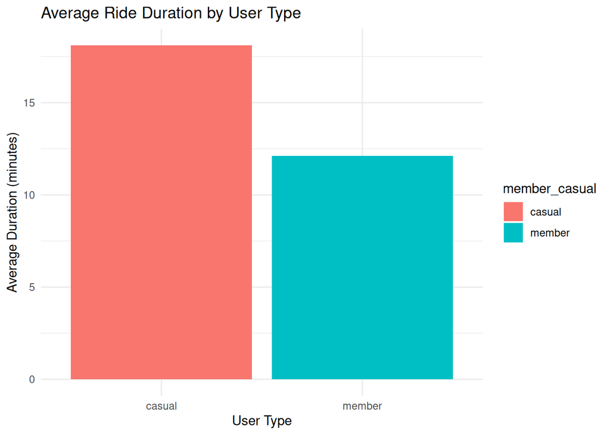

Casual riders take significantly longer trips on average compared to members, suggesting more recreational usage.

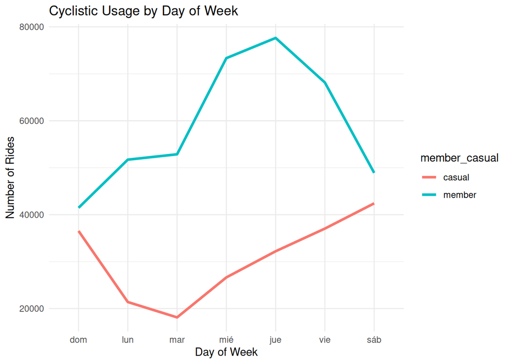

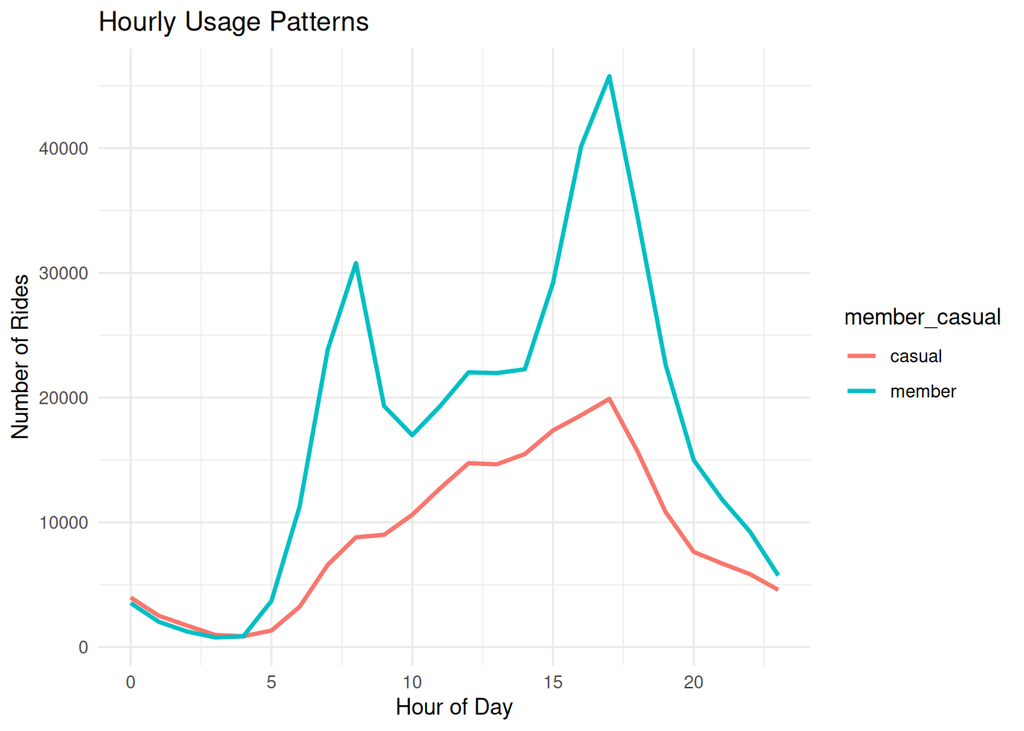

Members show strong commuting peaks around 8 AM and 5 PM, while casual riders concentrate usage midday and in late afternoon.

### **4.3 Key Behavioral Differences (Summary Table)**

This table summarizes the main measurable differences relevant to the business task.

**Key Behavioral Differences Between Rider Types**

[output not shown]

### **4.4 Executive Insights Summary**

**Business implication:** We are not targeting one group; we are targeting two different mindsets. Marketing to convert casual riders must appeal to their recreational, weekend-focused behavior and show them how a membership can enhance that experience.

### **4.5 Rideable Type Preferences**

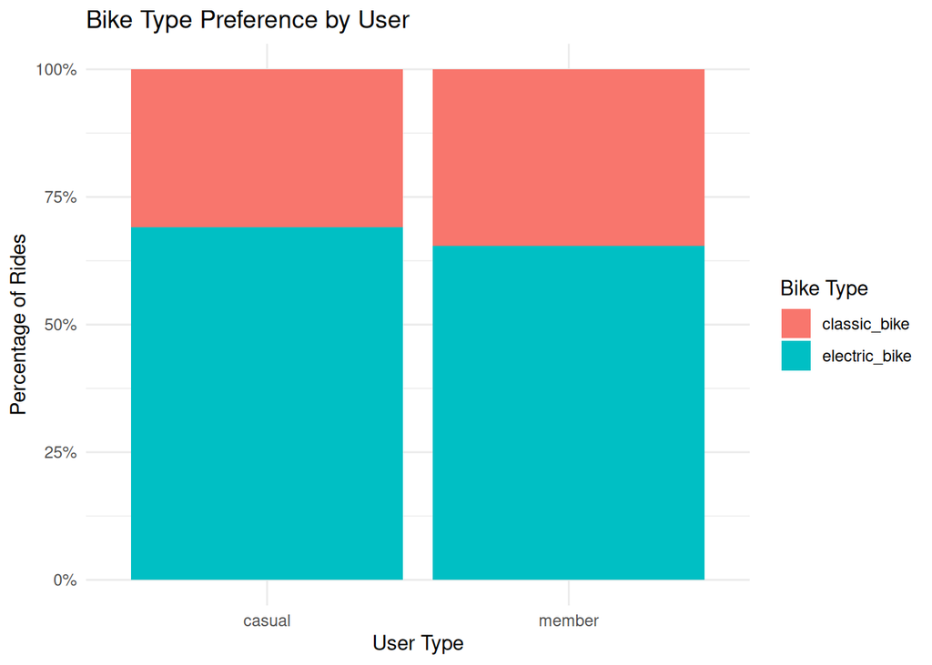

### **4.6 Top Stations Analysis**

To further support targeted marketing, this analysis identifies the most popular starting locations for each user group. The difference is stark and confirms the commuter vs. recreational narrative.

- **Member stations** are concentrated in residential neighborhoods and business districts.
- **Casual rider stations** are clustered around parks, tourist attractions, and waterfronts.

Top 5 Start Stations: Casual Riders

| start_station_name | Rides |
| --- | --- |
| Navy Pier | 4749 |
| DuSable Lake Shore Dr & Monroe St | 3092 |
| Michigan Ave & Oak St | 1914 |
| Millennium Park | 1731 |
| Shedd Aquarium | 1475 |

Top 5 Start Stations: Members

| start_station_name | Rides |
| --- | --- |
| Kingsbury St & Kinzie St | 3312 |
| Clinton St & Washington Blvd | 2773 |
| University Ave & 57th St | 2627 |
| Ellis Ave & 60th St | 2534 |
| Clinton St & Madison St | 2449 |

## **Phase 5: Share**

### **5.1 Key Findings**

These findings explain, in measurable terms, how both groups differ and why targeted marketing efforts should focus on converting casual riders.

### **5.2 How the Insights Were Communicated**

To ensure the results were understandable and actionable for Cyclistic stakeholders, the analysis was shared through a combination of:

- **A structured HTML report** (this document), which includes code, data cleaning logic, visualizations, and executive interpretation.
- **Clear visualizations** summarizing usage differences by duration, day of week, and hour of day.
- **A non-technical summary** designed for the Director of Marketing and business leadership.
- **A set of decision-ready insights**, directly tied to the business question of increasing annual memberships.

The communication emphasizes clarity, reproducibility, and alignment with the original business problem.

### **5.3 Visualizations Prepared for Stakeholders**

The following visualizations were included in the final stakeholder presentation:

Each visualization includes labeled axes, descriptive titles, and consistent color themes to support clarity and professional presentation.

### **5.4 Deliverable Summary**

The deliverable includes:

- A fully reproducible R Markdown report
- Cleaned and validated datasets
- Visualizations and summary tables aligned with Cyclistic’s business objectives
- Actionable, data-supported insights focused on converting casual riders into members

By presenting the findings in a clear and accessible way, this report ensures that technical and non-technical stakeholders can understand the patterns, support the conclusions, and make informed decisions about marketing strategy.

## **Phase 6: Act**

### **6.3 Measuring Success**

Success metrics should be aligned with business goals:

- **Increase annual membership conversions** among casual riders
- **Lower customer acquisition cost (CAC)** through targeted marketing
- **Higher trip frequency** among newly converted members
- **Improved seasonal retention**, particularly during summer and early fall

Monitoring these indicators ensures that Cyclistic can adjust its strategy and maintain long-term growth.

### **6.4 Final Summary**

The analysis demonstrates clear and measurable differences between casual riders and annual members. These differences directly inform marketing strategies that can encourage more casual riders to convert into members. By focusing on weekend-oriented behavior, leisure usage, and cost-effective incentives, Cyclistic can better align its services with rider needs and support its long-term goal of increasing annual memberships.

### **6.5 Future Analysis (Next Steps)**

To build on this report, the marketing analytics team should:

- **Perform a 12-Month Analysis:** Re-run this entire analysis on 12 months of data to confirm these patterns hold true across all seasons. This is essential before committing a large budget.
- **Analyze Ride Paths:** Use the start and end station data to see where casual riders are going (e.g., “Park -> Park” vs. “Park -> Museum”) to further refine marketing partnerships.